# North Carolina Project

## Impact of Tourism on Income in North Carolina

## Introduction

In this project, I will explore the relationship between tourism and income in North Carolina. As someone from a tourism-heavy county, I have heard various "takes" from different people - some who say that tourism raises income in our county and others who disagree. I wanted to use this project as an opportunity to explore what the facts behind that relationship are. In order to do this, I found data on the expected income of children who were born in a certain county and remained there into adulthood and compared this across North Carolina. This allows for a strict comparison of the individual counties without mobilization as a factor. Then, I compared this income data to data regarding tourism by county in NC. I decided to limit my analysis to purely North Carolina for two reasons. First, it is the only state whose tourism geography I know much about and would therefore be able to contextualize any outlying results. Second, it narrows the scope which in turn allows for more depth. Despite this, I suspect that the findings of this project likely has implications beyond North Carolina as well.

My data is from 4 locations. First, Opportunity Atlas (https://www.opportunityatlas.org/) is where I recieved data on expected income for children who remain in their counties. Their data additionally breaks down this expected income further into racial groups, gender, and parental income, of which only the latter was used. I am not aware of any specific analyses constructed off of this data but it is incredibly insightful into different geographical trends across the United States. Second, I used Visit NC (https://partners.visitnc.com/contents/sdownload/73486/file/2022+County+Level+Visitor+Expenditures.pdf) to find tourism data for each county. This data has been referenced in presentations at symposiums that I have attended regarding the impact of tourism in North Carolina, although I do not have a link or access to those presentations to provide here. Third, I used the North Carolina Association of County Commissioners (https://www.ncacc.org/wp-content/uploads/2024/02/2024_02_County-GDP.pdf) to find the GDP of each North Carolina county, which is used in the analysis. This data was manually inputted into in an excel document by me in combination with the VisitNC data. Finally, I used a geojson file from NCOneMap (https://www.nconemap.gov/datasets/NCEM-GIS::north-carolina-state-and-county-boundary-polygons/explore) in order to create the maps shown throughout the project. Similar to Opportunity Atlas, I don't know of any specific analysis done with either the NCACC or the NCOneMap data, however they are both quite useful and appear to be the most reliable data on their respective topics.

## Data wrangling: Importing Files, Creating and Merging Dataframes, Calculating Tourism as % of GDP, Finding Logs.

In order to clean and organize this data, the following steps were performed:

- The three files were read and saved as Panda's DataFrames or GeoDataFrames.
- Certain relevant columns within those files were selected for and inserted into new dataframes.
- Columns with complex names were renamed using a dictionary to increase accessibility.
- A calculation was performed to find Tourism as a percent of each county's GDP
- These new dataframes were joined with one another to make larger and more useful dataframes for further analysis.
- Log calculations were performed and saved as columns to be used in linear regression calculations.

```python
#Below, I am importing various packages that will be used throughout the project.
import numpy as np
import pandas as pd
import matplotlib.pyplot as plt
from matplotlib import image as mpimg
import statistics
import seaborn as sns
import geopandas as gpd
import statsmodels.api as sm
%matplotlib inline
```

```python
#Further code can be found in the Appendix.
```

## Visualizing the data: Plotting and Mapping Income Across North Carolina Income Percentiles

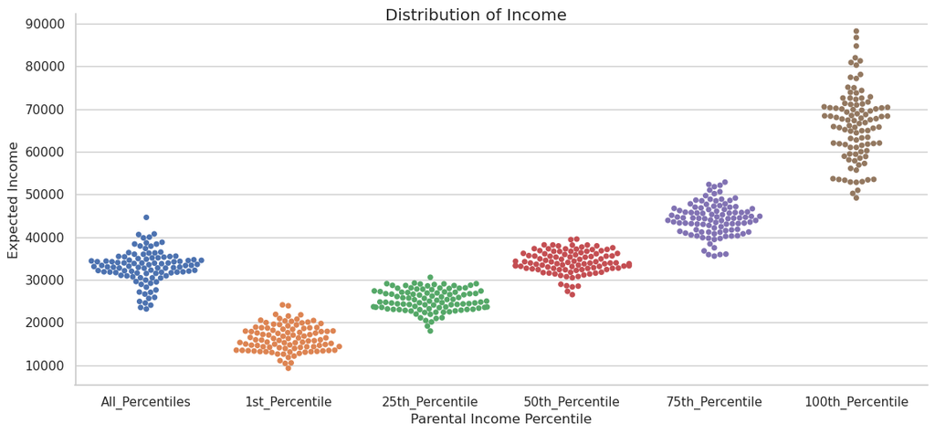

```python
#To set a theme
sns.set_theme(style="whitegrid")
#To create the plot
income_plot = sns.catplot(data = north_carolina_allr_allg,
                          kind = "swarm",height=5.2, aspect=2.2);
#To add axis labels
income_plot.set_axis_labels("Parental Income Percentile", "Expected Income");
income_plot.fig.suptitle("Distribution of Income");
```

In this plot, I visualised the expected income of children who remain in their birth county as adults, split by the income percentile of their parents. I did this to make sure that there are no clear outliers that need to be removed from the data, of which there are none. Substantively, this plot shows that the children of lower income parents can expect to make less money on average than the children of higher income parents in every county. It also shows that there is a significant amount of stratification between counties within the 100th percentile group, which will be explored further in relationship to the tourism industry in a future set of maps.

Before mapping the data, it is first important to highlight the different regions of North Carolina that I will be referring to throughout this section in order to orient youself within NC. In the below map, the color of a county demonstrates it's region. These regions are self-defined but are based on data found in this project as well as demographic knowledge and personal geocultural knowledge of the state.

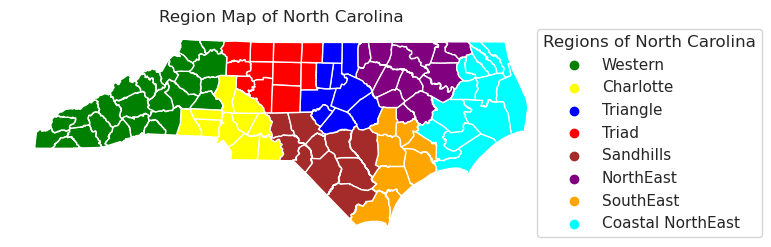

```python
#set figure size
fig, ax = plt.subplots(figsize=(7, 8))
#create the plot
NC_regions_geo.plot(color= NC_regions_geo["Color"], legend=True, ax = ax);
#turn off axis
ax.axis("off");
#create a for loop making labels for the legend
for region, color in color_dictionary_regions.items():
    ax.scatter([], [], color = color, label = region)
#making the legend
ax.legend(loc="center right", bbox_to_anchor =(1.4, 0.5),
          title="Regions of North Carolina");
#making the title
plt.title("Region Map of North Carolina");
```

Now, I will create a set of 4 subplots that show the geographic patterns of income across North Carolina.

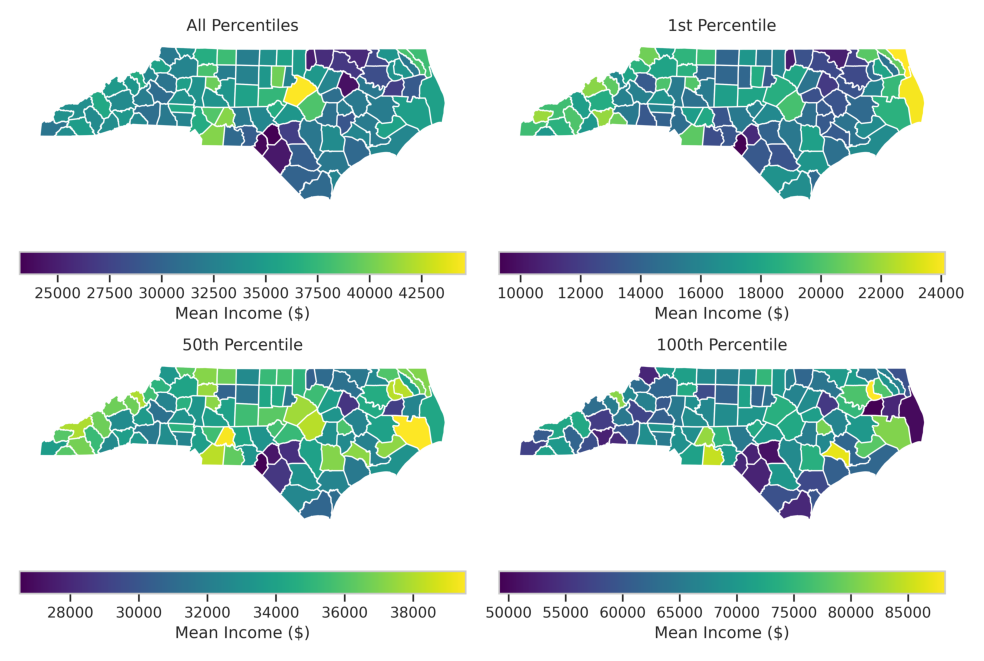

```python
#the code creating this figure can be found in the appendix.
distribution_of_income_img = mpimg.imread('income_percentiles_map.png')
#Set size
fig, ax = plt.subplots(figsize=(10, 7))
#Turn off axis
ax.set_axis_off()
#To make the maps fit well together
plt.tight_layout()
#Display the image
ax.imshow(distribution_of_income_img);
```

Here, I visualized 4 maps of North Carolina, separated by parental income percentile. Each of them acts independently of one another, shaded by each county's expected child income within the respective parental percentile. There appears to be a correlation between the highest performing counties for the lowest percentile and the lowest performing counties for the highest percentile.

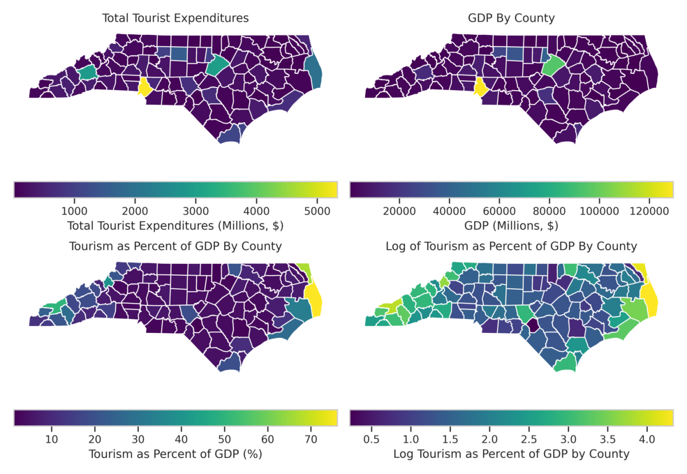

```python
#the code creating this figure can be found in the appendix.
t_g_img = mpimg.imread('tourism_gdp.png')
#Set size
fig, ax = plt.subplots(figsize=(10, 7))
#Turn off axis
ax.set_axis_off()
#To make the maps fit well together
plt.tight_layout()
#Display the image
ax.imshow(t_g_img);
```

These maps help to visualize certain economic trends within North Carolina. In the top two maps, it appears as though total tourist expenditures are correlated with the GDP of a county, with a few exceptions. However, if you analyze tourist expenditures as a percent of GDP, as is done in the bottom left map, that relationship disappears: in raw percentage terms, the Western and Coastal NorthEast regions attribute a greater portion of their economy to tourism than do the economically larger regions (Charlotte, The Triangle, and the Triad). This trend further continues once you normalize the percentages by taking the log of tourism as a percent of GDP. Here, the normalization allows for a greater color contrast between counties with low and high percents of their GDP attributed to tourism. These regional trends perpetuate in this bottom right map, with Western and Coastal Carolina drastically differing from other regions - with some exception like Moore County of the Sandhills region, which notably holds the US Open annually.

So far in our data, there appears to be a dynamic where Western and Coastal NorthEast North Carolina appear to have higher expected incomes for the lowest percentiles and simultaneously have a larger share of their economy be due to tourism, suggesting that higher levels of tourism relative to the local economy might be correlated with a higher expected income for these people. In this next section, we will examine the statistical validity of this potential relationship via linear regressions.

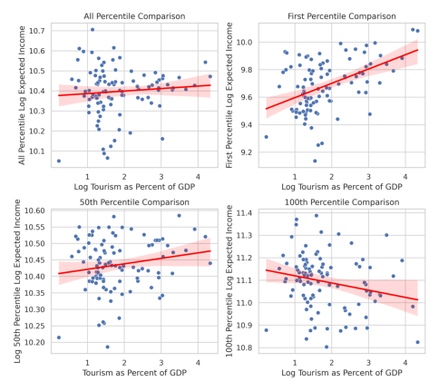

```python
#the code creating this figure can be found in the appendix.
reg_img = mpimg.imread("regressions.png")
#Set size
fig, ax = plt.subplots(figsize=(5, 5))
#Turn off axis
ax.set_axis_off()
#To make the plots fit well together
plt.tight_layout()
#Display the image
ax.imshow(reg_img);
```

These are scatterplots that show how the 4 percentile groups's log expected income relates to the log of Tourism as a percent of county GDP wherein each individual dot represents one of NC's 100 counties. The line overlaid in each plot is the Ordinary Least Squares regression of that plot, which represents the line with the lowest amount of total error possible that has a constant slope. In these regressions, it appears that the trends anticipated by the maps hold true: that an increase in log tourism as percent of GDP appears to be associated with an increase of log expected income for the lowest percentiles while it is associated with a decrease in log tourism for the highest percentiles. Therefore, if one's goal were to increase the income of the bottom percentile, increasing dependence on tourism might be effective.

## Analyses: Learning More Via Regression Statistics

The regression scatterplots showed some relationships between log tourism as percent of GDP and log expected income. Let's analyze how statistically significant those relationships are.

```python
# Create a new dataframe for the regression with relevant columns.
regression_data_1st = NC_complete[["logT-G", "logfirst"]]
# Extract the independent (X) and dependent (Y) variables
X_1st = regression_data_1st["logT-G"]
Y_1st = regression_data_1st["logfirst"]
# Add a Constant to the Independent Variable
X_1st = sm.add_constant(X_1st)
# Fit the Regression Model
model_1st = sm.OLS(Y_1st, X_1st)  # Ordinary Least Squares regression
results_1st = model_1st.fit()
# Print the results
print(results_1st.summary())
```

```
                            OLS Regression Results
==============================================================================
Dep. Variable:               logfirst   R-squared:                       0.216
Model:                            OLS   Adj. R-squared:                  0.208
Method:                 Least Squares   F-statistic:                     27.05
Date:                Sun, 08 Dec 2024   Prob (F-statistic):           1.09e-06
Time:                        13:07:42   Log-Likelihood:                 38.233
No. Observations:                 100   AIC:                            -72.47
Df Residuals:                      98   BIC:                            -67.25
Df Model:                           1
Covariance Type:            nonrobust
==============================================================================
                 coef    std err          t      P>|t|      [0.025      0.975]
------------------------------------------------------------------------------
const          9.4926      0.040    237.155      0.000       9.413       9.572
logT-G         0.1039      0.020      5.201      0.000       0.064       0.144
==============================================================================
Omnibus:                        2.040   Durbin-Watson:                   2.131
Prob(Omnibus):                  0.361   Jarque-Bera (JB):                1.466
Skew:                          -0.253   Prob(JB):                        0.480
Kurtosis:                       3.309   Cond. No.                         5.84
==============================================================================

Notes:
[1] Standard Errors assume that the covariance matrix of the errors is correctly specified.
```

## Conclusions

For the future, I think this research could be expanded upon to each county in the United States to provide a more national view of how tourism impacts different classes in our society. But even within North Carolina, I think that breaking the data down even further into not only how tourism affects expected income based on parental income but also on race and gender would be incredibly worthwile as well, given that the tourism and hospitality sectors are traditionally disproportionately female, it could be interesting to see whether or not women economically benefit from increased tourism more than men - or vice versa.

## Reflection

I think this project went quite well. I am specifically quite happy with the condition of the maps and other visualizations that I produced as part of this project. It was really interesting for me to see how findings of the data unfolded because this is a topic that has been at the forefront of my mind in recent years and I finally have conclusive evidence to at least part of the question of whether or not tourism is "good" or "bad" for the economy. I am also happy that I was able to run the linear regressions and that they revealed a statistically significant relationship.

For me, the most difficult part of this project was data wrangling. Specifically, the creation of new dataframes that involved combining multiple others was particularly challenging. Additionally, learning the code for the OLS regressions was difficult at first but luckily we learned similar models in lecture that allowed me to understand the code more deeply than if we had not done so. It was also difficult to comment exactly what my code is doing as often I would forget to do so as I was writing the code, so I had to reread through many of the lines in order to remember why I wrote a particular line. This was especially the case in the data cleaning and organization section of the project found in the appendix.

Initially, there were a few visualizations that I decided not to include in the final project. The first was a set of four plots that showed the relationship between GDP, Tourism, and percent of GDP as tourism. They were not included because I felt that they did not show any meaningful relationships that would help answer the central question of this research.

## Appendix

### Data Wrangling & Organization

```python
#Here, I am importing and saving the 3 files as Panda's
#dataframes or geodataframes.
Opportunity_Atlas = pd.read_csv("OpportunityAtlas.csv")
NC_counties_geo = gpd.read_file("North_Carolina_State_and_County_Boundary_Polygons.geojson")
NC_Econ_Data = pd.read_csv("NC_Econ_Data.csv")

#The Oppportunity_Atlas dataframe contains data from
#counties all over the United States.
#The code below is to create a new dataframe with a
#scope limited to NC.
columns = Opportunity_Atlas.columns
north_carolina = Opportunity_Atlas[Opportunity_Atlas['name'].str.contains('NC', case=True, na=False)]
north_carolina.reset_index()

#This dataframe contains 218 columns, so I want to
#reduce that to only those
#I will use: all races and all genders for each
#of the 6 parental income percentiles listed.
north_carolina_allr_allg = north_carolina[["name",
                                           "kfr_staycz_rP_gP_pall",
                                           "kfr_staycz_rP_gP_p1",
                                           "kfr_staycz_rP_gP_p25",
                                           "kfr_staycz_rP_gP_p50",
                                           "kfr_staycz_rP_gP_p75",
                                           "kfr_staycz_rP_gP_p100"]]

#These column names are complex, so I renamed
#them to easier to remember names.
rename_dict = {
    "name": "County_Name",
    "kfr_staycz_rP_gP_pall": "All_Percentiles",
    "kfr_staycz_rP_gP_p1": "1st_Percentile",
    "kfr_staycz_rP_gP_p25": "25th_Percentile",
    "kfr_staycz_rP_gP_p50": "50th_Percentile",
    "kfr_staycz_rP_gP_p75": "75th_Percentile",
    "kfr_staycz_rP_gP_p100": "100th_Percentile"}
north_carolina_allr_allg = north_carolina_allr_allg.rename(columns=rename_dict)

#Here, I make a new dataframe with just the
#useful columns of the
#geopandas dataframe so that I can join it to
#the cleaned Opportunity Atlas dataframe.
NC_geo = NC_counties_geo[["County", "geometry"]]
NC_geo = NC_geo.sort_values("County")
NC_geo = NC_geo.reset_index(drop = True)
#Then, I sort and reset the index of the
#Opportunity Atlas
#dataframe to make it easier to combine the data.
north_carolina_allr_allg = north_carolina_allr_allg.sort_values("County_Name")
north_carolina_allr_allg = north_carolina_allr_allg.reset_index(drop = True)
#Finally, I merge the two into a new dataframe that
#will be useful in mapping.
NC_geodata = NC_geo.join(north_carolina_allr_allg)

#To create the regional map, I printed the county
#names and
#manually created an additional dataframe that
#codes the region of each county.
#Since the data is sorted, I made this dataframe
#below to join
counties = NC_geodata['County_Name'].tolist()
regions = pd.Series(["Triad", "Western", "Western", "Charlotte", "Western",
                     "Western", "Coastal NorthEast",  "NorthEast", "Sandhills",
                     "SouthEast", "Western", "Western", "Charlotte", "Western",
                     "Coastal NorthEast", "Coastal NorthEast", "Triad", "Western",
                     "Triangle", "Western", "Coastal NorthEast", "Western",
                     "Charlotte", "Sandhills", "Coastal NorthEast", "Sandhills",
                     "Coastal NorthEast", "Coastal NorthEast", "Triad", "Triad",
                     "SouthEast", "Triangle", "NorthEast", "Triad", "NorthEast",
                     "Charlotte", "NorthEast", "Western", "Triangle", "NorthEast",
                     "Triad", "NorthEast", "Triangle", "Western", "Western",
                     "NorthEast", "Sandhills", "Coastal NorthEast", "Charlotte",
                     "Western", "Triangle", "SouthEast", "Triangle", "SouthEast",
                     "Charlotte", "Western", "Western", "NorthEast", "Western",
                     "Charlotte", "Western", "Sandhills", "Sandhills", "NorthEast",
                     "SouthEast",  "NorthEast", "SouthEast", "Triangle",
                     "Coastal NorthEast", "Coastal NorthEast", "SouthEast",
                     "Coastal NorthEast", "Triangle", "NorthEast", "Western",
                     "Triad", "Sandhills", "Sandhills", "Triad", "Charlotte",
                     "Western", "Sandhills", "Sandhills", "Charlotte", "Triad",
                     "Triad", "Western", "Western", "Coastal NorthEast", "Charlotte",
                     "NorthEast", "Triangle", "NorthEast", "Coastal NorthEast",
                     "Western", "SouthEast", "Western", "NorthEast",
                     "Triad", "Western"], name = "region")

#Now to make a new dataframe for the regions map.
NC_regions_geo = NC_geodata.join(regions)

#I also need to create a color dictionary
#for the regions map.
color_dictionary_regions = {"Western": "green",
                            "Charlotte": "yellow",
                            "Triangle": "blue",
                            "Triad": "red",
                            "Sandhills": "brown",
                            "NorthEast": "purple",
                            "SouthEast": "orange",
                            "Coastal NorthEast": "cyan"}
#And apply this to the NC_regions_geo dataframe.
NC_regions_geo["Color"] = NC_regions_geo["region"].map(color_dictionary_regions)

color_list = NC_regions_geo["Color"].tolist()

#Next, I create a new column in the NC_Econ_Data
#dataframe that has the percent
#of a county's
#GDP that tourism spending makes up.
#This will be useful in doing data analysis.
NC_Econ_Data["Tourism_as_percent_of_GDP"] = (NC_Econ_Data["Total_Tourist_Expenditures"]/ NC_Econ_Data["GDP"])*100

#Then, I clean and organize that data
#so that it can be joined with
#the geopandas dataframe for mapping purposes.
NC_Econ_Data = NC_Econ_Data.reset_index()
NC_Econ_Data = NC_Econ_Data[["Total_Tourist_Expenditures",
                             "GDP",
                             "Tourism_as_percent_of_GDP"]]
NC_Econ_geodata = NC_geo.join(NC_Econ_Data)

#Below, I create a dataframe with income data,
#tourism spending data, and GDP data that
#will be useful in doing
#linear regressions later.
NC_complete = north_carolina_allr_allg.join(NC_Econ_Data)

#Finally, I perform log calculations
#that are saved as columns to be used
#in linear regressions.
NC_complete["logT-G"] = np.log(NC_complete["Tourism_as_percent_of_GDP"])
NC_complete["logall"] = np.log(NC_complete["All_Percentiles"])
NC_complete["logfirst"] = np.log(NC_complete["1st_Percentile"])
NC_complete["log50th"] = np.log(NC_complete["50th_Percentile"])
NC_complete["log100th"] = np.log(NC_complete["100th_Percentile"])

#Then, I make this into a geopanda's
#dataframe for the purpose of mapping.
NC_complete.reset_index()
NC_complete_geo = NC_geo.join(NC_complete)
```

### Imaging (Mapping and Regression Plots) Code

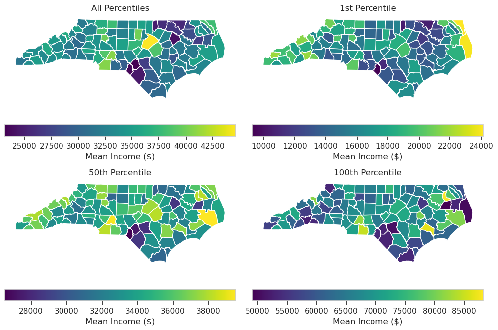

```python
#For space, I had to move the code to
#create the maps to the appendix.
#They are saved as png files and
#printed in the main project.
#For the first set of maps (income)
#To set a color theme
cmap = "viridis"

#To create the subplots structure and
#set the size of the total figure
fig, ax = plt.subplots(2, 2, figsize=(10, 7))

#To create the top left image -
#an All Percentiles map.
#Sets a title and turns off the axis as well.
ax[0,0].set_title("All Percentiles")
NC_geodata.plot(column="All_Percentiles",
                ax=ax[0, 0],
                legend=True, cmap = cmap,
                legend_kwds={'label': "Mean Income ($)",
                             'orientation': "horizontal"})
ax[0, 0].set_axis_off()

#To create the top right image -
#the 1st percentile.
#Sets a title and turns off
#the axis as well.
ax[0,1].set_title("1st Percentile")
NC_geodata.plot(column="1st_Percentile",
                ax=ax[0, 1], legend=True,
                cmap = cmap,
                legend_kwds={'label': "Mean Income ($)",
                             'orientation': "horizontal"})
ax[0, 1].set_axis_off()

#To create the bottom left image
#- the 50th Percentile.
#Sets a title and turns
#off the axis as well.
ax[1,0].set_title("50th Percentile")
NC_geodata.plot(column="50th_Percentile",
                ax=ax[1, 0],
                legend=True,
                cmap = cmap,
                legend_kwds={'label': "Mean Income ($)",
                             'orientation': "horizontal"})
ax[1, 0].set_axis_off()

#To create the bottom right map
#- the 100th percentile.
#Sets a title and turns
#off the axis as well.
ax[1,1].set_title("100th Percentile")
NC_geodata.plot(column="100th_Percentile",
                ax=ax[1, 1],
                legend=True,
                cmap = cmap,
                legend_kwds={'label': "Mean Income ($)",
                             'orientation': "horizontal"});
ax[1, 1].set_axis_off()

#To help the subplots look good
#visually and not overlap
#with one another.
plt.tight_layout()

#To save as a photo
distribution_of_income = "income_percentiles_map.png"
plt.savefig(distribution_of_income, dpi=500,
            bbox_inches='tight')
```

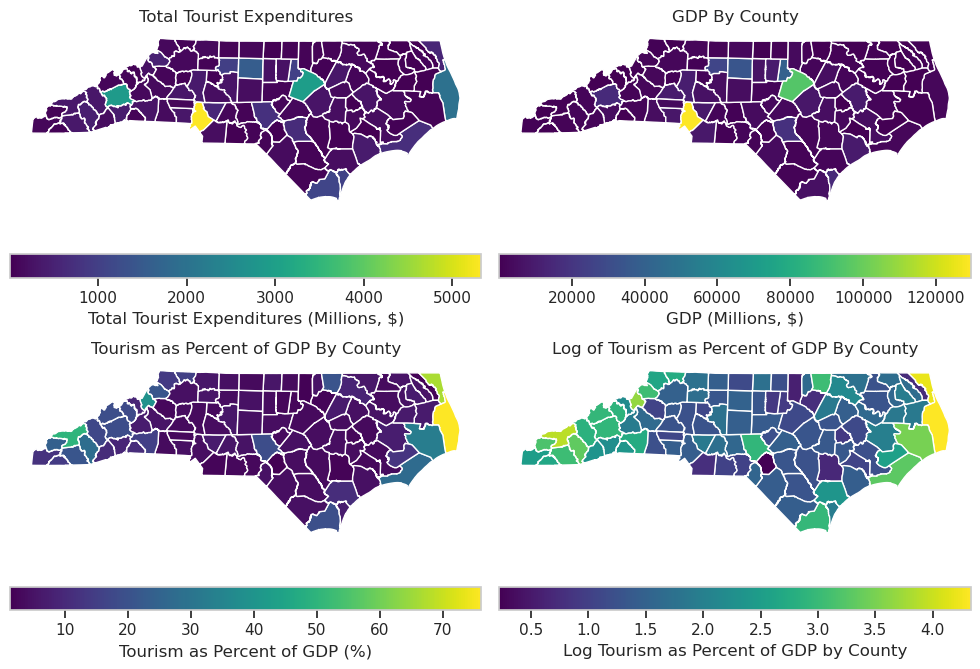

```python
#For the first set of maps
#(Tourism and GDP)
#To set the figure size.
fig, ax = plt.subplots(2, 2, figsize=(10, 7))

#To create the top left map -
#Total Tourist Expenditures,
#set a title, and turn axis off.
ax[0,0].set_title("Total Tourist Expenditures")
NC_Econ_geodata.plot(column="Total_Tourist_Expenditures",
                     ax=ax[0, 0],
                     legend=True,
                     cmap = cmap,
                legend_kwds={'label': "Total Tourist Expenditures (Millions, $)",
                             'orientation': "horizontal"})
ax[0, 0].set_axis_off()

#To create the top right map -
#GDP By County, set a title,
#and turn axis off.
ax[0,1].set_title("GDP By County")
NC_Econ_geodata.plot(column="GDP",
                     ax=ax[0, 1],
                     legend=True,
                     cmap = cmap,
                legend_kwds={'label': "GDP (Millions, $)",
                             'orientation': "horizontal"})
ax[0, 1].set_axis_off()

#To create the bottom left map
#- tourism as % of GDP by county,
#set a title, and turn axis off.
ax[1,0].set_title("Tourism as Percent of GDP By County")
NC_Econ_geodata.plot(column="Tourism_as_percent_of_GDP",
                     ax=ax[1, 0],
                     legend=True,
                     cmap = cmap,
                legend_kwds={'label': 'Tourism as Percent of GDP (%)',
                             'orientation': "horizontal"})
ax[1, 0].set_axis_off()

#To create the bottom right map
#- Log tourism as % of
#GDP by county, set a title,
#and turn axis off.
ax[1,1].set_title("Log of Tourism as Percent of GDP By County")
NC_complete_geo.plot(column="logT-G",
                     ax=ax[1, 1],
                     legend=True,
                     cmap = cmap,
                legend_kwds={'label': "Log Tourism as Percent of GDP by County",
                             'orientation': "horizontal"})
ax[1, 1].set_axis_off()

#To help the subplots fit
#together nicely
plt.tight_layout()

#To save as a photo
tourism_gdp_img = "tourism_gdp.png"
plt.savefig(tourism_gdp_img, dpi=500,
            bbox_inches='tight')
```

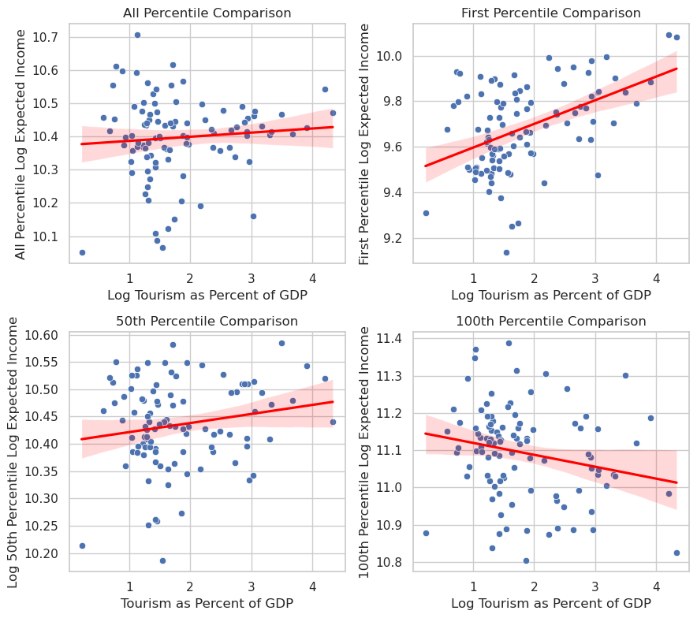

```python
#For the Regression Plot Image
#To create the figure size
fig, ax = plt.subplots(2, 2, figsize=(9, 8))

#To create the top left figure,
#all percentiles.
ax[0, 0].set_title("All Percentile Comparison");

#To create the scatterplot
sns.scatterplot(data = NC_complete,
                x = "logT-G",
                y = "logall",
                ax=ax[0,0]);
#to create the regression line
sns.regplot(data = NC_complete,
            x = "logT-G",
            y = "logall",
            ax=ax[0,0],
            scatter = False,
           line_kws = {"color":"red"},
            order = 1);
#To set its axis labels.
ax[0, 0].set_ylabel("All Percentile Log Expected Income");
ax[0,0].set_xlabel("Log Tourism as Percent of GDP");

#To create the top right figure,
#first percentile.
ax[0, 1].set_title("First Percentile Comparison");

#To create the scatterplot
sns.scatterplot(data = NC_complete,
                x = "logT-G",
                y = "logfirst",
                ax=ax[0,1]);
#to create the regression line
sns.regplot(data = NC_complete,
            x = "logT-G",
            y = "logfirst",
            ax=ax[0,1],
            scatter = False,
           line_kws = {"color":"red"},
            order = 1);
#To set its axis labels.
ax[0, 1].set_ylabel("First Percentile Log Expected Income");
ax[0,1].set_xlabel("Log Tourism as Percent of GDP");

#To create the bottom left
#figure, 50th percentile.
ax[1,0].set_title("50th Percentile Comparison");

#To create the scatterplot
sns.scatterplot(data = NC_complete,
                x = "logT-G",
                y = "log50th",
                ax=ax[1,0]);
#to create the regression line
sns.regplot(data = NC_complete,
            x = "logT-G",
            y = "log50th",
            ax=ax[1,0],
            scatter = False,
           line_kws = {"color":"red"},
            order = 1);
#To set its axis labels.
ax[1, 0].set_ylabel("Log 50th Percentile Log Expected Income");
ax[1, 0].set_xlabel("Tourism as Percent of GDP");

#To create the bottom right
#figure, 100th percentile.
ax[1, 1].set_title("100th Percentile Comparison");

#To create the scatterplot
sns.scatterplot(data = NC_complete,
                x = "logT-G",
                y = "log100th",
                ax=ax[1,1]);
#to create the regression line
sns.regplot(data = NC_complete,
            x = "logT-G",
            y = "log100th",
            ax=ax[1,1],
            scatter = False,
           line_kws = {"color":"red"},
            order = 1);
#To set its axis labels.
ax[1, 1].set_ylabel("100th Percentile Log Expected Income");
ax[1, 1].set_xlabel("Log Tourism as Percent of GDP");

#To help the subplots fit
#together nicely
plt.tight_layout();


#To save as a photo
regressions_img = "regressions.png"
plt.savefig(regressions_img,
            dpi=500,
            bbox_inches='tight')
```